# 제 11강: 선형모형 2

데이터과학 입문

Author

Affiliation

원중호

서울대학교 통계학과

Published

April 2026

## 시작하기 전에

다음의 패키지가 설치되어 있지 않으면 설치한다.

**R**

```r
# install.packages("MASS")
# install.packages("tidyverse")
# install.packages("kableExtra") # for pretty tables
# install.packages("patchwork")  # for side-by-side ggplots
# install.packages("multcomp")  # for multiple comparisons
library(MASS)
library(tidyverse)
library(kableExtra)
library(patchwork)
library(multcomp)
```

**Python**

```python
import session_info
import numpy as np
import pandas as pd
import polars as pl
from plotnine import *
import matplotlib.pyplot as plt
import statsmodels.api as sm
import statsmodels.formula.api as smf
from statsmodels.stats.anova import anova_lm

session_info.show()
```

```
-----
matplotlib          3.10.8
numpy               2.4.3
pandas              3.0.1
plotnine            0.15.3
polars              1.38.1
session_info        1.0.0
statsmodels         0.14.6
-----
Python 3.12.12 | packaged by conda-forge | (main, Jan 27 2026, 00:04:03) [Clang 19.1.7 ]
macOS-26.2-arm64-arm-64bit
-----
Session information updated at 2026-04-27 00:25
```

# 회귀 진단

## 회귀 진단

- Whiteside 자료는 적절한 선형 모형을 찾기 쉬운 편이나 일반적으로 하나 혹은 그 이상의 점들이 적합되지 않거나 그 점들이 모형 적합에 큰 영향을 끼쳤는지를 평가하기 위한 연구가 많이 되어 있다 (Atkinson, 1985).

## 잔차

- 회귀 진단의 기본 도구
- 잔차 이용의 예: 경향성 유무, 분포의 정규성 진단
- 잔차는 서로 독립이 아님 (절편 항이 있으면 잔차합이 0)
- 잔차는 등분산이 아님
- 잔차 공분산 행렬
  $$\operatorname{cov}(\mathbf{e}) = \sigma^2 (I_n - H), \quad H=X(X^T X)^{-1} X^T$$
  - $H$ : hat matrix, 모형 공간으로의 직교사영행렬 ($\hat{\mathbf{y}} = H\mathbf{y}$)
- 지렛대값(leverage)
  - $h_{ii}$ = $H$의 $i$번째 대각원소, 관측값 $y_{i}$의 지렛대
    - $h_{ii}$ 값이 크면 $y_i$가 변화할 때 적합평면이 바뀐 값 쪽으로 크게 이동한다.
  - $\operatorname{tr}(H)=p$, 모형 공간의 차원 또는 공변량의 갯수
  - “$h_{ii}$가 크다”의 기준: $p/n = \frac{1}{n}\sum_{i=1}^n h_{ii}$의 2 또는 3배

## 스튜던트화 잔차

- 만약 잔차값 하나가 너무 크면 분산의 추정치 $s^2$도 아주 클 것이고, 이로 인해 모든 표준화 잔차값들을 수축시킴
- 스튜던트화 잔차 (잭나이프화 잔차, jackknifed residual)
  $$e_{i}^{*} =
  \frac{y_i - \hat{y}_{(i)}}{\sqrt{\operatorname{var}(y_i - \hat{y}_{(i)})}}
  =
  \frac{y_i - \hat{y}_{(i)}}{s_{(i)}\sqrt{1-h_{ii}}}, \quad i=1, \dotsc, n$$
  - $\widehat{y}_{(i)}$ = $i$번째 관측치를 제외한 나머지 관측치들로 적합한 모형으로 구한 $i$번 째 종속변수의 예측치
  - $s_{(i)}^{2}$ = $i$번 째 관측치를 제외한 나머지 관측치들로 적합한 모형으로 구한 오차의 평균제곱합
- 관측치를 제외할 때마다 모형을 새로 적합하는 계산을 하지 않아도 됨:
  $$e_{i}^{*} = e_{i}^{\prime} \left[ \frac{n-p-{{e}_{i}^{\prime}}^2}{n-p-1} \right]^{1/2}, \quad i=1, \dotsc, n$$
  임이 알려져 있다.
  - $|e_{i}^{\prime}| \le \sqrt{n-p}, \quad i=1,2, \dots, n$
- 보통 스튜던트화 잔차를 비교하는 것이 잔차를 비교하는 것보다 좋음.

## Scottish hill races 자료

**R**

```r
as.tibble(MASS::hills)
```

```
# A tibble: 35 × 3
    dist climb  time
   <dbl> <int> <dbl>
 1   2.5   650  16.1
 2   6    2500  48.4
 3   6     900  33.6
 4   7.5   800  45.6
 5   8    3070  62.3
 6   8    2866  73.2
 7  16    7500 205.
 8   6     800  36.4
 9   5     800  29.8
10   6     650  39.8
# ℹ 25 more rows
```

**Python**

```python
hills = sm.datasets.get_rdataset("hills", "MASS").data
# hills.info()
hills.head(10)
```

```
              dist  climb     time
rownames
Greenmantle    2.5    650   16.083
Carnethy       6.0   2500   48.350
Craig Dunain   6.0    900   33.650
Ben Rha        7.5    800   45.600
Ben Lomond     8.0   3070   62.267
Goatfell       8.0   2866   73.217
Bens of Jura  16.0   7500  204.617
Cairnpapple    6.0    800   36.367
Scolty         5.0    800   29.750
Traprain       6.0    650   39.750
```

- 변수 : 달리기의 전체 거리, 총 등반 높이, 소요 시간

**R**

```r
(hills.lm <-  lm(time ~ dist + climb, data = hills))
```

```
Call:
lm(formula = time ~ dist + climb, data = hills)

Coefficients:
(Intercept)         dist        climb
   -8.99204      6.21796      0.01105
```

**Python**

```python
hills_lm = smf.ols(formula='time ~ dist + climb', data=hills).fit()
hills_lm.summary()
```

OLS Regression Results

| Dep. Variable: | time | R-squared: | 0.919 |
| --- | --- | --- | --- |
| Model: | OLS | Adj. R-squared: | 0.914 |
| Method: | Least Squares | F-statistic: | 181.7 |
| Date: | Mon, 27 Apr 2026 | Prob (F-statistic): | 3.40e-18 |
| Time: | 00:25:14 | Log-Likelihood: | -142.11 |
| No. Observations: | 35 | AIC: | 290.2 |
| Df Residuals: | 32 | BIC: | 294.9 |
| Df Model: | 2 |  |  |
| Covariance Type: | nonrobust |  |  |

|  | coef | std err | t | P>\|t\| | [0.025 | 0.975] |
| --- | --- | --- | --- | --- | --- | --- |
| Intercept | -8.9920 | 4.303 | -2.090 | 0.045 | -17.756 | -0.228 |
| dist | 6.2180 | 0.601 | 10.343 | 0.000 | 4.993 | 7.442 |
| climb | 0.0110 | 0.002 | 5.387 | 0.000 | 0.007 | 0.015 |

| Omnibus: | 47.910 | Durbin-Watson: | 2.249 |
| --- | --- | --- | --- |
| Prob(Omnibus): | 0.000 | Jarque-Bera (JB): | 233.976 |
| Skew: | 3.026 | Prob(JB): | 1.56e-51 |
| Kurtosis: | 14.127 | Cond. No. | 4.20e+03 |

Notes:  
[1] Standard Errors assume that the covariance matrix of the errors is correctly specified.  
[2] The condition number is large, 4.2e+03. This might indicate that there are  
strong multicollinearity or other numerical problems.

**R**

```r
# 스튜던트화 잔차도 (MASS::studres)
par(fig = c(x1 = 0,  x2 = 0.6,  y1 = 0, y2 = 1))
plot(fitted(hills.lm), MASS::studres(hills.lm), pch = 16)
abline(h = 0, lty = 2)
# Two large residual points
ord <- order(MASS::studres(hills.lm), decreasing=T)
x1 <- fitted(hills.lm)[ord][1]
x2 <- fitted(hills.lm)[ord][2]
y1 <- MASS::studres(hills.lm)[ord][1]
y2 <- MASS::studres(hills.lm)[ord][2]
text(x = x1, y = y1, label = names(y1), pos=4)
text(x = x2, y = y2, label = names(y2), pos=2)
# Quantile-quantile plot
par(fig = c(0.6,  1,  0,  1), new = T)
qqnorm(MASS::studres(hills.lm), pch = 16,
       xlab = "Quantiles of Standard Normal",
       ylab = "studres(hills.lm)", main = NULL)
qqline(MASS::studres(hills.lm))
```

**Python**

```python
from scipy.stats import zscore
from statsmodels.stats.outliers_influence import OLSInfluence

influence = OLSInfluence(hills_lm)
studres = influence.resid_studentized_external

# Studentized residual plot
plt.figure(figsize=(8, 6))
plt.scatter(hills_lm.fittedvalues, studres, c='black', marker='o')
plt.axhline(y=0, linestyle='dashed', color='black')
plt.xlabel('Fitted values')
plt.ylabel('Studentized residuals')

# Two large residual points
res_ord = studres.sort_values(ascending=False)
x1 = hills_lm.fittedvalues.loc[res_ord.index[0]]
x2 = hills_lm.fittedvalues.loc[res_ord.index[1]]
y1 = studres.loc[res_ord.index[0]]
y2 = studres.loc[res_ord.index[1]]
plt.text(x1, y1, '  '+res_ord.index[0], horizontalalignment='left')
plt.text(x2, y2, res_ord.index[1]+'  ', horizontalalignment='right')
plt.show()

# Quantile-quantile plot
sm.qqplot(studres, line='45', fit=True)
plt.xlabel('Quantiles of Standard Normal')
plt.ylabel('Studentized residuals')
plt.tight_layout()
plt.show()
```

**R**

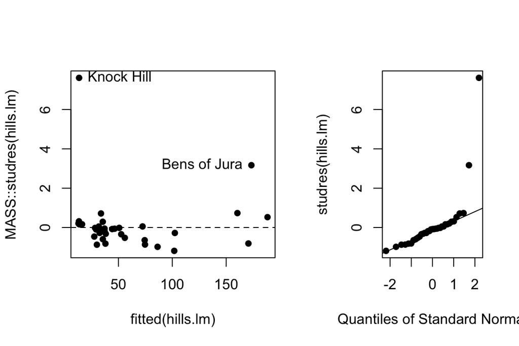

**Python**

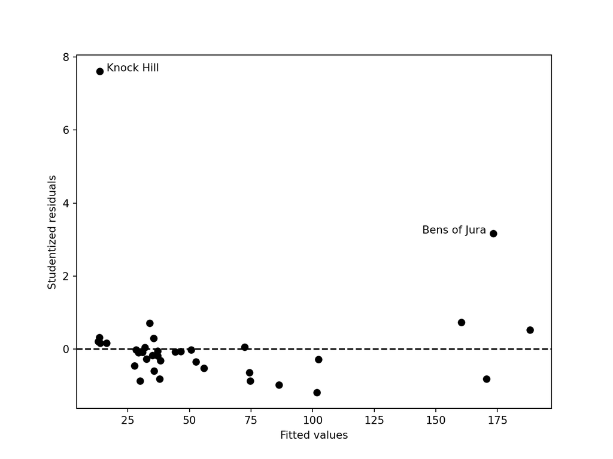

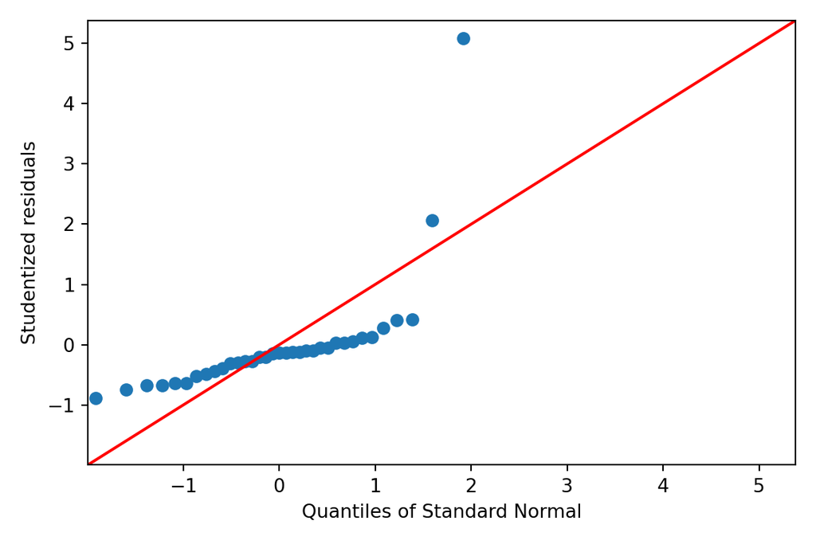

**R**

```r
hills.hat <- lm.influence(hills.lm)$hat  # leverage
cbind(hills, lev = hills.hat) [hills.hat > 3/35,  ]
```

```
              dist climb    time       lev
Bens of Jura    16  7500 204.617 0.4204346
Lairig Ghru     28  2100 192.667 0.6898161
Ben Nevis       10  4400  85.583 0.1215821
Two Breweries   18  5200 170.250 0.1715848
Moffat Chase    20  5000 159.833 0.1909891
```

**Python**

```python
hills_hat = influence.hat_matrix_diag
hills2 = hills.copy()
hills2['lev'] = hills_hat
hills2[hills_hat > 3/35]
```

```
               dist  climb     time       lev
rownames
Bens of Jura   16.0   7500  204.617  0.420435
Lairig Ghru    28.0   2100  192.667  0.689816
Ben Nevis      10.0   4400   85.583  0.121582
Two Breweries  18.0   5200  170.250  0.171585
Moffat Chase   20.0   5000  159.833  0.190989
```

- 지렛대 값이 높은 점이 2개이고, 스튜던트화 잔차가 큰 점도 2개이다. Bens of Jura는 두 가지 모두에 포함된다.
- Knock Hill을 보면, 실제 기록보다 예측이 1시간 (60분)이상 작다.

**R**

```r
cbind(hills, pred = predict(hills.lm))["Knock Hill",]
```

```
           dist climb  time    pred
Knock Hill    3   350 78.65 13.5286
```

**Python**

```python
hills3 = hills.copy()
hills3['pred'] = hills_lm.predict(hills)
hills3.loc[['Knock Hill']]
```

```
            dist  climb   time       pred
rownames
Knock Hill   3.0    350  78.65  13.528597
```

- 기록에 1시간 정도 오차가 있는 것으로 보인다 (Atkinson, 1988). 따라서 Knock Hill 관측치를 제외하자.

**R**

```r
(hills1.lm <- update(hills.lm,
                     subset = !(rownames(hills) %in% c("Knock Hill"))
                     )
 )
```

```
Call:
lm(formula = time ~ dist + climb, data = hills, subset = !(rownames(hills) %in%
    c("Knock Hill")))

Coefficients:
(Intercept)         dist        climb
  -13.53035      6.36456      0.01185
```

**Python**

```python
hills_mod = hills.loc[~hills.index.isin(['Knock Hill'])]
hills1_lm = smf.ols(formula='time ~ dist + climb', data=hills_mod).fit()
hills1_lm.summary()
```

OLS Regression Results

| Dep. Variable: | time | R-squared: | 0.972 |
| --- | --- | --- | --- |
| Model: | OLS | Adj. R-squared: | 0.970 |
| Method: | Least Squares | F-statistic: | 530.9 |
| Date: | Mon, 27 Apr 2026 | Prob (F-statistic): | 1.04e-24 |
| Time: | 00:25:14 | Log-Likelihood: | -120.63 |
| No. Observations: | 34 | AIC: | 247.3 |
| Df Residuals: | 31 | BIC: | 251.8 |
| Df Model: | 2 |  |  |
| Covariance Type: | nonrobust |  |  |

|  | coef | std err | t | P>\|t\| | [0.025 | 0.975] |
| --- | --- | --- | --- | --- | --- | --- |
| Intercept | -13.5304 | 2.649 | -5.108 | 0.000 | -18.933 | -8.127 |
| dist | 6.3646 | 0.361 | 17.624 | 0.000 | 5.628 | 7.101 |
| climb | 0.0119 | 0.001 | 9.600 | 0.000 | 0.009 | 0.014 |

| Omnibus: | 6.584 | Durbin-Watson: | 1.893 |
| --- | --- | --- | --- |
| Prob(Omnibus): | 0.037 | Jarque-Bera (JB): | 5.898 |
| Skew: | 0.579 | Prob(JB): | 0.0524 |
| Kurtosis: | 4.680 | Cond. No. | 4.31e+03 |

Notes:  
[1] Standard Errors assume that the covariance matrix of the errors is correctly specified.  
[2] The condition number is large, 4.31e+03. This might indicate that there are  
strong multicollinearity or other numerical problems.

- Knock Hill은 지렛대 값이 크지 않다. 따라서 Knock Hill을 제거하는 것은 적합된 모형을 크게 바꾸지는 않는다.
- 반면, Bens of Jura는 지렛대 값이 크고, 잔차도 크므로 적합된 모형에 영향이 있을 것이다.

**R**

```r
update(hills.lm,
       subset = !(rownames(hills) %in% c("Knock Hill", "Bens of Jura"))
       )
```

```
Call:
lm(formula = time ~ dist + climb, data = hills, subset = !(rownames(hills) %in%
    c("Knock Hill", "Bens of Jura")))

Coefficients:
(Intercept)         dist        climb
 -10.361646     6.692114     0.008047
```

**Python**

```python
hills_mod2 = hills.loc[~hills.index.isin(['Knock Hill','Bens of Jura'])]
hills2_lm = smf.ols(formula='time ~ dist + climb', data=hills_mod2).fit()
hills2_lm.summary()
```

OLS Regression Results

| Dep. Variable: | time | R-squared: | 0.982 |
| --- | --- | --- | --- |
| Model: | OLS | Adj. R-squared: | 0.981 |
| Method: | Least Squares | F-statistic: | 835.3 |
| Date: | Mon, 27 Apr 2026 | Prob (F-statistic): | 4.99e-27 |
| Time: | 00:25:14 | Log-Likelihood: | -104.68 |
| No. Observations: | 33 | AIC: | 215.4 |
| Df Residuals: | 30 | BIC: | 219.8 |
| Df Model: | 2 |  |  |
| Covariance Type: | nonrobust |  |  |

|  | coef | std err | t | P>\|t\| | [0.025 | 0.975] |
| --- | --- | --- | --- | --- | --- | --- |
| Intercept | -10.3616 | 1.898 | -5.460 | 0.000 | -14.237 | -6.486 |
| dist | 6.6921 | 0.254 | 26.312 | 0.000 | 6.173 | 7.212 |
| climb | 0.0080 | 0.001 | 7.573 | 0.000 | 0.006 | 0.010 |

| Omnibus: | 7.588 | Durbin-Watson: | 2.070 |
| --- | --- | --- | --- |
| Prob(Omnibus): | 0.023 | Jarque-Bera (JB): | 6.098 |
| Skew: | 0.844 | Prob(JB): | 0.0474 |
| Kurtosis: | 4.259 | Cond. No. | 3.82e+03 |

Notes:  
[1] Standard Errors assume that the covariance matrix of the errors is correctly specified.  
[2] The condition number is large, 3.82e+03. This might indicate that there are  
strong multicollinearity or other numerical problems.

### 선형모형의 개선

1. 경주의 거리가 짧으면 기록 시간이 음수이다. 물리적으로 절편이 0인 것이 바람직하다.

```r
summary(hills1.lm)$coefficients
```

```
               Estimate  Std. Error   t value     Pr(>|t|)
(Intercept) -13.5303520 2.649100461 -5.107527 1.578034e-05
dist          6.3645623 0.361129680 17.624035 1.043662e-17
climb         0.0118549 0.001234846  9.600304 8.412002e-11
```

2. 예측한 시간의 정확도가 그 시간에 반비례할 필요가 있다. 시간 대신 거리를 이용한 가중치를 주어 모형을 적합하자.

**R**

```r
summary(update(hills1.lm, weights =  1/(dist^2)))$coefficients
```

```
                Estimate  Std. Error   t value     Pr(>|t|)
(Intercept) -5.808538089 2.034247813 -2.855374 7.602533e-03
dist         5.820759581 0.536083931 10.857926 4.330482e-12
climb        0.009029245 0.001537499  5.872685 1.763612e-06
```

**Python**

```python
weights = 1 / (hills_mod['dist'] ** 2)
hills_weight_lm = smf.wls(formula='time ~ dist + climb', data=hills_mod, weights=weights).fit()
coefficients_summary = pd.DataFrame({
'Estimate': hills_weight_lm.params,
'Std. Error': hills_weight_lm.bse,
't value': hills_weight_lm.tvalues,
'Pr(>|t|)': hills_weight_lm.pvalues
})
print(coefficients_summary)
```

```
           Estimate  Std. Error    t value      Pr(>|t|)
Intercept -5.808538    2.034248  -2.855374  7.602533e-03
dist       5.820760    0.536084  10.857926  4.330482e-12
climb      0.009029    0.001537   5.872685  1.763612e-06
```

- 절편의 추정치는 여전히 통계적으로 유의하게 0이 아니므로 절편이 0인 모형을 적합.

**R**

```r
lm(time ~ -1 + dist + climb,
   data=(hills %>%
           filter(! (rownames(.) %in% c("Knock Hill")))),
   weights = 1/(dist^2))
```

```
Call:
lm(formula = time ~ -1 + dist + climb, data = (hills %>% filter(!(rownames(.) %in%
    c("Knock Hill")))), weights = 1/(dist^2))

Coefficients:
    dist     climb
4.899985  0.008472
```

**Python**

```python
hills_weight_zero_lm = smf.wls(formula='time ~ -1 + dist + climb', data=hills_mod, weights=weights).fit()
hills_weight_zero_lm.summary()
```

WLS Regression Results

| Dep. Variable: | time | R-squared (uncentered): | 0.970 |
| --- | --- | --- | --- |
| Model: | WLS | Adj. R-squared (uncentered): | 0.968 |
| Method: | Least Squares | F-statistic: | 523.4 |
| Date: | Mon, 27 Apr 2026 | Prob (F-statistic): | 3.59e-25 |
| Time: | 00:25:15 | Log-Likelihood: | -118.54 |
| No. Observations: | 34 | AIC: | 241.1 |
| Df Residuals: | 32 | BIC: | 244.1 |
| Df Model: | 2 |  |  |
| Covariance Type: | nonrobust |  |  |

|  | coef | std err | t | P>\|t\| | [0.025 | 0.975] |
| --- | --- | --- | --- | --- | --- | --- |
| dist | 4.9000 | 0.474 | 10.344 | 0.000 | 3.935 | 5.865 |
| climb | 0.0085 | 0.002 | 5.022 | 0.000 | 0.005 | 0.012 |

| Omnibus: | 6.572 | Durbin-Watson: | 1.985 |
| --- | --- | --- | --- |
| Prob(Omnibus): | 0.037 | Jarque-Bera (JB): | 6.925 |
| Skew: | 0.445 | Prob(JB): | 0.0313 |
| Kurtosis: | 5.024 | Cond. No. | 607. |

Notes:  
[1] R² is computed without centering (uncentered) since the model does not contain a constant.  
[2] Standard Errors assume that the covariance matrix of the errors is correctly specified.

**R**

```r
hills$ispeed <- hills$time / hills$dist
hills$grad   <- hills$climb / hills$dist
(hills2.lm <- lm(ispeed ~ grad,
                 data = (hills %>%
                           filter(! (rownames(.) %in% c("Knock Hill")))
                         )
                 )
)
```

```
Call:
lm(formula = ispeed ~ grad, data = (hills %>% filter(!(rownames(.) %in%
    c("Knock Hill")))))

Coefficients:
(Intercept)         grad
   4.899985     0.008472
```

**Python**

```python
hills['ispeed']= hills['time'] / hills['dist']
hills['grad']= hills['climb'] / hills['dist']
hills_mod3 = hills.loc[~hills.index.isin(['Knock Hill'])]
hills3_lm = smf.ols(formula = 'ispeed ~ grad', data=hills_mod3).fit()
hills3_lm.summary()
```

OLS Regression Results

| Dep. Variable: | ispeed | R-squared: | 0.441 |
| --- | --- | --- | --- |
| Model: | OLS | Adj. R-squared: | 0.423 |
| Method: | Least Squares | F-statistic: | 25.22 |
| Date: | Mon, 27 Apr 2026 | Prob (F-statistic): | 1.86e-05 |
| Time: | 00:25:15 | Log-Likelihood: | -55.569 |
| No. Observations: | 34 | AIC: | 115.1 |
| Df Residuals: | 32 | BIC: | 118.2 |
| Df Model: | 1 |  |  |
| Covariance Type: | nonrobust |  |  |

|  | coef | std err | t | P>\|t\| | [0.025 | 0.975] |
| --- | --- | --- | --- | --- | --- | --- |
| Intercept | 4.9000 | 0.474 | 10.344 | 0.000 | 3.935 | 5.865 |
| grad | 0.0085 | 0.002 | 5.022 | 0.000 | 0.005 | 0.012 |

| Omnibus: | 6.572 | Durbin-Watson: | 1.985 |
| --- | --- | --- | --- |
| Prob(Omnibus): | 0.037 | Jarque-Bera (JB): | 6.925 |
| Skew: | 0.445 | Prob(JB): | 0.0313 |
| Kurtosis: | 5.024 | Cond. No. | 607. |

Notes:  
[1] Standard Errors assume that the covariance matrix of the errors is correctly specified.

**R**

```r
# (Studentized) residual plot
par(fig = c(x1 = 0,  x2 = 0.6,  y1 = 0, y2 = 1))
plot(hills$grad[-ord[1]], studres(hills2.lm), xlab = "grad", pch = 16)
abline(h = 0, lty = 2)
sr <- studres(hills2.lm)
w <- c(abs(sr)>2)
text(x = hills2.lm$model$grad[w], y = sr[w], label = names(sr)[w], pos=2)
# Q-Q plot
par(fig = c(0.6,  1,  0,  1), new = T)
qqnorm(studres(hills2.lm), pch = 16,
       xlab = "Quantiles of Standard Normal",
       ylab = "studres(hills2.lm)", main = NULL)
qqline(studres(hills2.lm))
```

**Python**

```python
# (Studentized) residual plot
influence3 = OLSInfluence(hills3_lm)
studres3 = influence3.resid_studentized_external
w = abs(studres3) > 2

plt.figure(figsize=(8, 6))
plt.scatter(hills_mod3['grad'], studres3, c='black', marker='o')
plt.axhline(y=0, linestyle='dashed', color='black')
plt.xlabel('grad')
plt.ylabel('studres')
for x_val, y_val, label, is_outlier in zip(hills_mod3['grad'], studres3, studres3.index, w):
    if is_outlier:
        # Adding a small space in the string "{}  " for padding
        plt.text(x_val, y_val, f"{label}  ",
                 horizontalalignment='right',
                 verticalalignment='center')
plt.show()

sm.qqplot(studres3, line='45', fit=True)
plt.xlabel('Quantiles of Standard Normal')
plt.ylabel('studres')
plt.show()
```

**R**

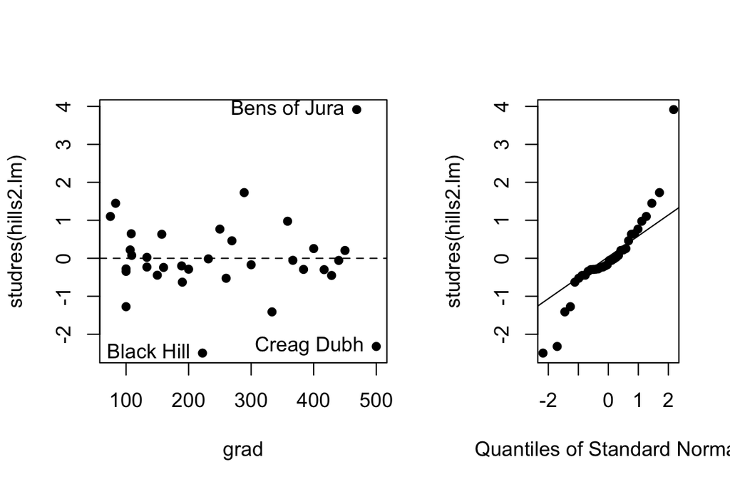

**Python**

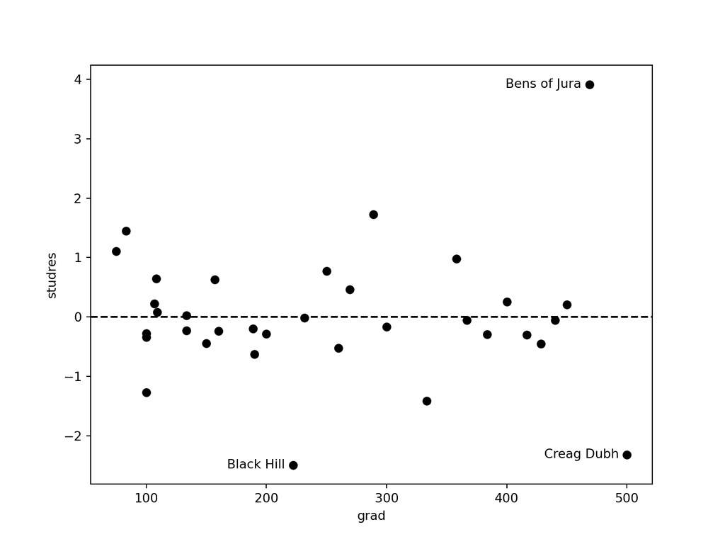

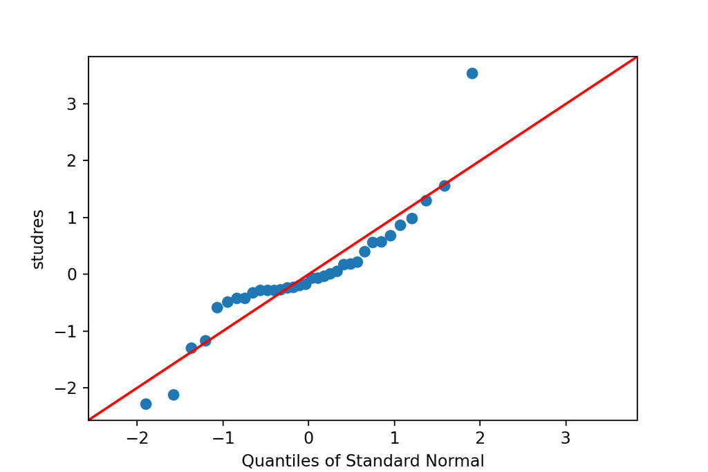

```r
hills2.hat <- lm.influence(hills2.lm)$hat  # leverage
hills %>% filter(!(rownames(.) %in% c("Knock Hill"))) %>%
  mutate(lev = hills2.hat) %>%
  filter(lev > 1.8*2/(nrow(hills)-1))
```

```
             dist climb    time   ispeed   grad       lev
Bens of Jura   16  7500 204.617 12.78856 468.75 0.1135367
Creag Dubh      4  2000  26.217  6.55425 500.00 0.1391534
```

- 지렛대 값이 가장 큰 두 경기는 가장 가파른 두 경기로, 서로 반대 방향으로 당기는 이상점이다. 대부분의 자료에 대해 1마일당 5분 및 1000피트당 8분의 예측이 들어맞는다.

# 선형모형의 부트스트랩

## 선형모형 돌아보기

$$y = \boldsymbol{\beta}^T\mathbf{x} + \boldsymbol{\epsilon}$$

1. 고정설계(fixed design)
   - $\boldsymbol{\epsilon}$만 확률변수로 봄.
   - 모든 (가정적) 반복된 관측에서 같은 점 $\mathbf{x}$들에 대해 반응변수의 값은 다를 수 있음
   - 실험 계획법(NPK 실험, 6.7절) , 정해진 요인이 있는 관찰 연구(Quine 자료, 6.8절)
2. 랜덤설계(random design)
   - 관측된 순서쌍 $(\mathbf{x}_i, y_i)$들이 모집단으로부터의 랜덤표본으로 간주됨.
   - 관심사: 회귀함수 $f(\mathbf{x})=E(Y|X=\mathbf{x})$의 추정, $f(\mathbf{x}) = \boldsymbol{\beta}^T\mathbf{x}$.
   - Whiteside, Scottish hills race 자료 등; calibration 혹은 errors-in-variable 문제
   - 조건부 추론: 즉, 관측된 $\mathbf{x}$에 조건부. 고정설계로 변환.
     - 예: Scottish hills race 자료에서의 추론들은 특정 경기(특히 Bens of Jura)가 표본에 포함되어 있는가에 의존.
- 선형회귀모형에서의 부트스트랩 재표집
  1. 사례 기반 재표집: 표본으로부터 순서쌍 $(x_i, y_i)$을 복원추출. 랜덤 가중회귀에 대응.
  2. 모형 기반 재표집: 잔차를 복원추출
     $$y_i^* = \widehat{\beta}^T\mathbf{x}_i + e^*_i$$
     - $\widehat{\beta}$ = 적합된 회귀계수 추정량
     - $e^*_i$ : 잔차 $e_i$들로부터 복원추출한 오차
- 모형 기반 재표집의 문제점
  1. 절편이 없는 모형에서는 잔차의 평균이 0이 아닐 수 있음
     - 평균 제거
  2. 잔차의 분산이 모형 오차의 분산과 같지 않고, 등분산이 아닐 수 있다.
     - 수정 잔차 $r_i = e_i / \sqrt{1-h_{ii}}$로부터 재표집. $var(r_i) = \sigma^2$.

**R**

```r
library(boot)
fit <-  lm(calls ~  year,  data = phones)
ph  <-  data.frame(phones,  res = resid(fit), fitted = fitted(fit))
ph.lm.boot <-  boot(ph,  function(data,  i) {
                            d  <-  data
                            d$calls <-  d$fitted +  d$res[i]
                            coef(update (fit, data=d))
                         }, R = 999)  %>% print
```

```
ORDINARY NONPARAMETRIC BOOTSTRAP


Call:
boot(data = ph, statistic = function(data, i) {
    d <- data
    d$calls <- d$fitted + d$res[i]
    coef(update(fit, data = d))
}, R = 999)


Bootstrap Statistics :
       original      bias    std. error
t1* -260.059246 -1.50701138   98.553007
t2*    5.041478  0.02193037    1.588059
```

**Python**

```python
from scipy.stats import bootstrap

phones = sm.datasets.get_rdataset("phones", "MASS").data
model = smf.ols("calls ~ year", data=phones).fit()
res = model.resid.values
fitted = model.fittedvalues.values
res_boot = bootstrap(
    (np.arange(len(phones)),),
    lambda i: smf.ols("calls ~ year",
                      data=phones.assign(calls=fitted + res[i])).fit().params.values,
    n_resamples=999,
    vectorized=False,
    method='percentile'
)

boot_stats = res_boot.bootstrap_distribution
# Replicating R's summary style for 't'
print(f"\nTotal Replicates: {boot_stats.shape[1]}")
```

```
Total Replicates: 999
```

```python
print(f"Mean of Bootstrap Slopes: {np.mean(boot_stats[1, :])}")
```

```
Mean of Bootstrap Slopes: 5.021173499624398
```

```python
print(f"Std. Error of Bootstrap Slopes: {np.std(boot_stats[1, :], ddof=1)}")
```

```
Std. Error of Bootstrap Slopes: 1.5816042286090095
```

**R**

```r
boot.ci(ph.lm.boot, index=1, type=c("basic", "bca"))  # intercept
```

```
BOOTSTRAP CONFIDENCE INTERVAL CALCULATIONS
Based on 999 bootstrap replicates

CALL :
boot.ci(boot.out = ph.lm.boot, type = c("basic", "bca"), index = 1)

Intervals :
Level      Basic                BCa
95%   (-456.3,  -66.0 )   (-457.3,  -74.7 )
Calculations and Intervals on Original Scale
```

```r
boot.ci(ph.lm.boot, index=2, type=c("basic", "bca"))  # slope
```

```
BOOTSTRAP CONFIDENCE INTERVAL CALCULATIONS
Based on 999 bootstrap replicates

CALL :
boot.ci(boot.out = ph.lm.boot, type = c("basic", "bca"), index = 2)

Intervals :
Level      Basic                BCa
95%   ( 1.901,  8.141 )   ( 2.043,  8.335 )
Calculations and Intervals on Original Scale
```

**Python**

```python
res_boot.confidence_interval
```

```
ConfidenceInterval(low=array([-441.52933736,    1.83190221]), high=array([-59.7256056 ,   8.08685843]))
```

```python
bca_boot = bootstrap(
    (np.arange(len(phones)),),
    lambda i: smf.ols("calls ~ year",
                      data=phones.iloc[i].assign(calls=fitted[i] + res[i])
                     ).fit().params.values,
    n_resamples=999,
    vectorized=False,
    method='BCa'
)
bca_boot.confidence_interval
```

```
ConfidenceInterval(low=array([-491.10030812,    2.0383858 ]), high=array([-88.91419711,   9.04019619]))
```

# 요인설계와 실험계획법

## NPK (Nitrogen, Phosphate, Potassium) 요인 실험

- 완두콩 재배에서의 질소, 인, 칼륨의 영향

```r
npk %>% knitr::kable(booktab=F) %>%
  kableExtra::kable_styling() %>%
  kableExtra::row_spec( which(as.integer(npk$block) %% 2 == 1),
                        color = "black", background = "lightgrey")
```

| block | N | P | K | yield |
| --- | --- | --- | --- | --- |
| 1 | 0 | 1 | 1 | 49.5 |
| 1 | 1 | 1 | 0 | 62.8 |
| 1 | 0 | 0 | 0 | 46.8 |
| 1 | 1 | 0 | 1 | 57.0 |
| 2 | 1 | 0 | 0 | 59.8 |
| 2 | 1 | 1 | 1 | 58.5 |
| 2 | 0 | 0 | 1 | 55.5 |
| 2 | 0 | 1 | 0 | 56.0 |
| 3 | 0 | 1 | 0 | 62.8 |
| 3 | 1 | 1 | 1 | 55.8 |
| 3 | 1 | 0 | 0 | 69.5 |
| 3 | 0 | 0 | 1 | 55.0 |
| 4 | 1 | 0 | 0 | 62.0 |
| 4 | 1 | 1 | 1 | 48.8 |
| 4 | 0 | 0 | 1 | 45.5 |
| 4 | 0 | 1 | 0 | 44.2 |
| 5 | 1 | 1 | 0 | 52.0 |
| 5 | 0 | 0 | 0 | 51.5 |
| 5 | 1 | 0 | 1 | 49.8 |
| 5 | 0 | 1 | 1 | 48.8 |
| 6 | 1 | 0 | 1 | 57.2 |
| 6 | 1 | 1 | 0 | 59.0 |
| 6 | 0 | 1 | 1 | 53.2 |
| 6 | 0 | 0 | 0 | 56.0 |

- 부분요인설계 — 6개의 실험 블록 각각에서 완전설계($8=2^3$)의 절반이 시행 (블록 1, 5, 6 = N + P + K 짝수번)
- N, P, K의 각 조합은 전체 블록에 걸쳐 3번씩 나타남.

## ANOVA

**R**

```r
options(contrasts = c("contr.helmert", "contr.poly")) # Helmert contrast
npk.aov <- aov(yield ~ block + N*P*K, data = npk) %>% print
```

```
Call:
   aov(formula = yield ~ block + N * P * K, data = npk)

Terms:
                   block        N        P        K      N:P      N:K      P:K
Sum of Squares  343.2950 189.2817   8.4017  95.2017  21.2817  33.1350   0.4817
Deg. of Freedom        5        1        1        1        1        1        1
                Residuals
Sum of Squares   185.2867
Deg. of Freedom        12

Residual standard error: 3.929447
1 out of 13 effects not estimable
Estimated effects are balanced
```

**Python**

```python
from patsy.contrasts import Helmert, Poly

npk = sm.datasets.get_rdataset("npk", "datasets").data
# Q("yield") handles the reserved keyword 'yield'
# C(variable, Helmert) sets the contrast type explicitly
formula = 'Q("yield") ~ C(block, Helmert) + C(N, Helmert) * C(P, Helmert) * C(K, Helmert)'
model = smf.ols(formula, data=npk).fit()

# typ=1 matches R's sequential sum of squares (aov)
anova_table = sm.stats.anova_lm(model, typ=1)
print(anova_table)
```

```
                                             df  ...    PR(>F)
C(block, Helmert)                           5.0  ...  0.015939
C(N, Helmert)                               1.0  ...  0.004372
C(P, Helmert)                               1.0  ...  0.474904
C(K, Helmert)                               1.0  ...  0.028795
C(N, Helmert):C(P, Helmert)                 1.0  ...  0.263165
C(N, Helmert):C(K, Helmert)                 1.0  ...  0.168648
C(P, Helmert):C(K, Helmert)                 1.0  ...  0.862752
C(N, Helmert):C(P, Helmert):C(K, Helmert)   1.0  ...  0.017658
Residual                                   12.0  ...       NaN

[9 rows x 5 columns]
```

**R**

```r
summary(npk.aov)
```

```
            Df Sum Sq Mean Sq F value  Pr(>F)
block        5  343.3   68.66   4.447 0.01594 *
N            1  189.3  189.28  12.259 0.00437 **
P            1    8.4    8.40   0.544 0.47490
K            1   95.2   95.20   6.166 0.02880 *
N:P          1   21.3   21.28   1.378 0.26317
N:K          1   33.1   33.14   2.146 0.16865
P:K          1    0.5    0.48   0.031 0.86275
Residuals   12  185.3   15.44
---
Signif. codes:  0 '***' 0.001 '**' 0.01 '*' 0.05 '.' 0.1 ' ' 1
```

```r
coef(npk.aov)
```

```
(Intercept)      block1      block2      block3      block4      block5
 54.8750000   1.7125000   1.6791667  -1.8229167  -1.0137500   0.2950000
         N1          P1          K1       N1:P1       N1:K1       P1:K1
  2.8083333  -0.5916667  -1.9916667  -0.9416667  -1.1750000   0.1416667
```

**Python**

```python
model.summary()
```

OLS Regression Results

| Dep. Variable: | Q("yield") | R-squared: | 0.789 |
| --- | --- | --- | --- |
| Model: | OLS | Adj. R-squared: | 0.595 |
| Method: | Least Squares | F-statistic: | 4.069 |
| Date: | Mon, 27 Apr 2026 | Prob (F-statistic): | 0.0116 |
| Time: | 00:25:20 | Log-Likelihood: | -58.581 |
| No. Observations: | 24 | AIC: | 141.2 |
| Df Residuals: | 12 | BIC: | 155.3 |
| Df Model: | 11 |  |  |
| Covariance Type: | nonrobust |  |  |

|  | coef | std err | t | P>\|t\| | [0.025 | 0.975] |
| --- | --- | --- | --- | --- | --- | --- |
| Intercept | 54.8750 | 0.802 | 68.415 | 0.000 | 53.127 | 56.623 |
| C(block, Helmert)[H.2] | 0.7369 | 0.790 | 0.933 | 0.369 | -0.984 | 2.458 |
| C(block, Helmert)[H.3] | 1.3540 | 0.790 | 1.714 | 0.112 | -0.367 | 3.075 |
| C(block, Helmert)[H.4] | -1.9855 | 0.570 | -3.484 | 0.005 | -3.227 | -0.744 |
| C(block, Helmert)[H.5] | -0.7211 | 0.462 | -1.562 | 0.144 | -1.727 | 0.285 |
| C(block, Helmert)[H.6] | 0.4901 | 0.374 | 1.310 | 0.215 | -0.325 | 1.305 |
| C(N, Helmert)[H.1] | 2.8083 | 0.802 | 3.501 | 0.004 | 1.061 | 4.556 |
| C(P, Helmert)[H.1] | -0.5917 | 0.802 | -0.738 | 0.475 | -2.339 | 1.156 |
| C(K, Helmert)[H.1] | -1.9917 | 0.802 | -2.483 | 0.029 | -3.739 | -0.244 |
| C(N, Helmert)[H.1]:C(P, Helmert)[H.1] | -0.9417 | 0.802 | -1.174 | 0.263 | -2.689 | 0.806 |
| C(N, Helmert)[H.1]:C(K, Helmert)[H.1] | -1.1750 | 0.802 | -1.465 | 0.169 | -2.923 | 0.573 |
| C(P, Helmert)[H.1]:C(K, Helmert)[H.1] | 0.1417 | 0.802 | 0.177 | 0.863 | -1.606 | 1.889 |
| C(N, Helmert)[H.1]:C(P, Helmert)[H.1]:C(K, Helmert)[H.1] | 0.9756 | 0.628 | 1.552 | 0.147 | -0.394 | 2.345 |

| Omnibus: | 1.162 | Durbin-Watson: | 2.853 |
| --- | --- | --- | --- |
| Prob(Omnibus): | 0.559 | Jarque-Bera (JB): | 0.942 |
| Skew: | -0.229 | Prob(JB): | 0.624 |
| Kurtosis: | 2.144 | Cond. No. | 1.52e+16 |

Notes:  
[1] Standard Errors assume that the covariance matrix of the errors is correctly specified.  
[2] The smallest eigenvalue is 5.46e-31. This might indicate that there are  
strong multicollinearity problems or that the design matrix is singular.

- 블록이 교락변수로 작용하여 N:P:K 교호작용은 추정할 수 없다 (예: $b_2 + b_3 + b_4 - b_1 - b_5 - b_6 = N*P*K$, $\pm 1$ 코딩시).
- N:P:K 교호작용은 `summary()`에서 생략됨
- 어떤 효과들이 생략되었나?

**R**

```r
alias(npk.aov)
```

```
Model :
yield ~ block + N * P * K

Complete :
         (Intercept) block1 block2 block3 block4 block5 N1    P1    K1    N1:P1
N1:P1:K1     0           1    1/3    1/6  -3/10   -1/5      0     0     0     0
         N1:K1 P1:K1
N1:P1:K1     0     0
```

**Python**

```python
import numpy as np
import pandas as pd

# 1. Identify Aliased (Redundant) Terms
# In statsmodels, aliased terms are usually dropped, resulting in NaN coefficients
aliased_terms = model.params[model.params.isna()]

if not aliased_terms.empty:
    print("Aliased Terms (Perfectly Collinear):")
    print(aliased_terms)
else:
    # 2. Check for hidden aliases via the Design Matrix Rank
    # We compare the number of columns to the actual rank
    design_matrix = model.model.exog
    rank = np.linalg.matrix_rank(design_matrix)
    num_vars = design_matrix.shape[1]

    if rank < num_vars:
        print(f"Model is Rank Deficient: {num_vars - rank} term(s) are aliased.")
    else:
        print("No aliased terms found.")
```

```
Model is Rank Deficient: 1 term(s) are aliased.
```

- 각 행의 열들은 헹에 선형 종속되는 효과에 해당

## 표준오차

- N과 K의 주효과들만 유의하므로, 축소된 모형을 적합

**R**

```r
options(contrasts = c("contr.treatment", "contr.poly")) # 처리 대조로 복원
npk.aov1 <- aov(yield ~ block + N + K, data = npk)
summary.lm(npk.aov1)
```

```
Call:
aov(formula = yield ~ block + N + K, data = npk)

Residuals:
    Min      1Q  Median      3Q     Max
-6.4083 -2.1438  0.2042  2.3292  7.0750

Coefficients:
            Estimate Std. Error t value Pr(>|t|)
(Intercept)   53.208      2.276  23.381  8.5e-14 ***
block2         3.425      2.787   1.229  0.23690
block3         6.750      2.787   2.422  0.02769 *
block4        -3.900      2.787  -1.399  0.18082
block5        -3.500      2.787  -1.256  0.22723
block6         2.325      2.787   0.834  0.41646
N1             5.617      1.609   3.490  0.00302 **
K1            -3.983      1.609  -2.475  0.02487 *
---
Signif. codes:  0 '***' 0.001 '**' 0.01 '*' 0.05 '.' 0.1 ' ' 1

Residual standard error: 3.942 on 16 degrees of freedom
Multiple R-squared:  0.7163,    Adjusted R-squared:  0.5922
F-statistic: 5.772 on 7 and 16 DF,  p-value: 0.001805
```

**Python**

```python
model_new = smf.ols('Q("yield") ~ C(block,Treatment) + C(N,Treatment) + C(K,Treatment)', data=npk).fit()
npk_aov1 = sm.stats.anova_lm(model_new, typ=1)
model_new.summary()
```

OLS Regression Results

| Dep. Variable: | Q("yield") | R-squared: | 0.716 |
| --- | --- | --- | --- |
| Model: | OLS | Adj. R-squared: | 0.592 |
| Method: | Least Squares | F-statistic: | 5.772 |
| Date: | Mon, 27 Apr 2026 | Prob (F-statistic): | 0.00181 |
| Time: | 00:25:20 | Log-Likelihood: | -62.107 |
| No. Observations: | 24 | AIC: | 140.2 |
| Df Residuals: | 16 | BIC: | 149.6 |
| Df Model: | 7 |  |  |
| Covariance Type: | nonrobust |  |  |

|  | coef | std err | t | P>\|t\| | [0.025 | 0.975] |
| --- | --- | --- | --- | --- | --- | --- |
| Intercept | 53.2083 | 2.276 | 23.381 | 0.000 | 48.384 | 58.033 |
| C(block, Treatment)[T.2] | 3.4250 | 2.787 | 1.229 | 0.237 | -2.484 | 9.334 |
| C(block, Treatment)[T.3] | 6.7500 | 2.787 | 2.422 | 0.028 | 0.841 | 12.659 |
| C(block, Treatment)[T.4] | -3.9000 | 2.787 | -1.399 | 0.181 | -9.809 | 2.009 |
| C(block, Treatment)[T.5] | -3.5000 | 2.787 | -1.256 | 0.227 | -9.409 | 2.409 |
| C(block, Treatment)[T.6] | 2.3250 | 2.787 | 0.834 | 0.416 | -3.584 | 8.234 |
| C(N, Treatment)[T.1] | 5.6167 | 1.609 | 3.490 | 0.003 | 2.205 | 9.028 |
| C(K, Treatment)[T.1] | -3.9833 | 1.609 | -2.475 | 0.025 | -7.395 | -0.572 |

| Omnibus: | 0.100 | Durbin-Watson: | 2.904 |
| --- | --- | --- | --- |
| Prob(Omnibus): | 0.951 | Jarque-Bera (JB): | 0.145 |
| Skew: | -0.117 | Prob(JB): | 0.930 |
| Kurtosis: | 2.700 | Cond. No. | 8.45 |

Notes:  
[1] Standard Errors assume that the covariance matrix of the errors is correctly specified.

- 질소와 칼륨을 가하는 효과는 각각 5.62와 -3.98임
- 대조변수의 표준오차

**R**

```r
se.contrast(npk.aov1, list(N ==  "0",  N ==  "1"), data =  npk)
```

```
[1] 1.609175
```

```r
se.contrast(npk.aov1, list(K ==  "0",  K ==  "1"), data =  npk)
```

```
[1] 1.609175
```

**Python**

```python
# This contains the variances of the betas and their covariances
V = model.cov_params()
# Define the contrast vector for Nitrogen (N)
# Since N is binary, the contrast is simply the coefficient for N
n_effect_name = [name for name in model.params.index if 'C(N' in name][0]
# SE for the Nitrogen contrast
se_n = np.sqrt(V.loc[n_effect_name, n_effect_name])
# SE For the contrast between two means (N0 vs N1):
sed_n = 2 * se_n
print(f"SED (Difference between N0 and N1): {sed_n:.4f}")
```

```
SED (Difference between N0 and N1): 1.6042
```

```python
# SE for the Potassium  contrast
k_effect_name = [name for name in model.params.index if 'C(K' in name][0]
se_k = np.sqrt(V.loc[k_effect_name, k_effect_name])
sed_k = 2 * se_k
print(f"SED (Difference between K0 and K1): {sed_k:.4f}")
```

```
SED (Difference between K0 and K1): 1.6042
```

# Quine 자료와 불균형 4원배치

## 자료

**R**

```r
as.tibble(MASS::quine)
```

```
# A tibble: 146 × 5
   Eth   Sex   Age   Lrn    Days
   <fct> <fct> <fct> <fct> <int>
 1 A     M     F0    SL        2
 2 A     M     F0    SL       11
 3 A     M     F0    SL       14
 4 A     M     F0    AL        5
 5 A     M     F0    AL        5
 6 A     M     F0    AL       13
 7 A     M     F0    AL       20
 8 A     M     F0    AL       22
 9 A     M     F1    SL        6
10 A     M     F1    SL        6
# ℹ 136 more rows
```

**Python**

```python
quine = sm.datasets.get_rdataset("quine","MASS").data
quine.head(10)
```

```
  Eth Sex Age Lrn  Days
0   A   M  F0  SL     2
1   A   M  F0  SL    11
2   A   M  F0  SL    14
3   A   M  F0  AL     5
4   A   M  F0  AL     5
5   A   M  F0  AL    13
6   A   M  F0  AL    20
7   A   M  F0  AL    22
8   A   M  F1  SL     6
9   A   M  F1  SL     6
```

- 반응변수(`Days`): 호주, 뉴사우스 웨일즈 주의 대도시의 아이들이 1년 간 학교에 결석한 날짜 수
- 설명변수
  - `Age`: 4 levels. Primary, first, second or third form (`F0`–`F3`)
  - `Eth`: 2 levels. Aboriginal or non-aboriginal
  - `Lrn`: 2 levels. Slow or average learner
  - `Sex`: 2 levels. Male or female
- 도수분포표

**R**

```r
xtabs(~ Lrn + Age + Sex + Eth, data=quine)
```

```
, , Sex = F, Eth = A

    Age
Lrn  F0 F1 F2 F3
  AL  4  5  1  9
  SL  1 10  8  0

, , Sex = M, Eth = A

    Age
Lrn  F0 F1 F2 F3
  AL  5  2  7  7
  SL  3  3  4  0

, , Sex = F, Eth = N

    Age
Lrn  F0 F1 F2 F3
  AL  4  6  1 10
  SL  1 11  9  0

, , Sex = M, Eth = N

    Age
Lrn  F0 F1 F2 F3
  AL  6  2  7  7
  SL  3  7  3  0
```

**Python**

```python
xtab = pd.crosstab(
    index=[quine['Lrn'], quine['Age']],
    columns=[quine['Sex'], quine['Eth']],
    dropna=False  # Keeps categories even if they have 0 counts
)
print(xtab)
```

```
Sex       F      M
Eth       A   N  A  N
Lrn Age
AL  F0    4   4  5  6
    F1    5   6  2  2
    F2    1   1  7  7
    F3    9  10  7  7
SL  F0    1   1  3  3
    F1   10  11  3  7
    F2    8   9  4  3
    F3    0   0  0  0
```

불균형 자료 – 학습속도가 느린 학생은 F3에는 없고 그 외의 28개의 조합에는 1명 이상 있다.

- 이분산성(heteroskedasticity)

**R**

```r
# the tidyverse way
quinestat <- quine %>% group_by(Eth, Sex, Age, Lrn) %>%
  summarize(Mean = mean(Days, na.rm=TRUE),
            Var = var(Days, na.rm=TRUE), SD = sd(Days, na.rm=TRUE))
varplot <- ggplot(quinestat, aes(x = Mean, y = Var)) + geom_point() +
            labs(x = "Cell Means", y = "Cell Variances")
sdplot  <- ggplot(quinestat, aes(x = Mean, y = SD))  + geom_point() +
            labs(x = "Cell Means", y = "Cell Std Devn.")
varplot + sdplot
```

**Python**

```python
quinestat = (
    quine.groupby(['Eth', 'Sex', 'Age', 'Lrn'])['Days']
    .agg(Mean='mean', Var='var', SD='std')
    .reset_index()
)
varplot = (
    ggplot(quinestat, aes(x='Mean', y='Var'))
    + geom_point()
    + labs(title="Variance vs Mean", x="Cell Means", y="Cell Variances")
)
sdplot = (
    ggplot(quinestat, aes(x='Mean', y='SD'))
    + geom_point()
    + labs(title="Std Dev vs Mean", x="Cell Means", y="Cell Std Devn.")
)
varplot.show()
sdplot.show()
```

결측값은 그래프를 그릴 때 자동적으로 생략.

**R**

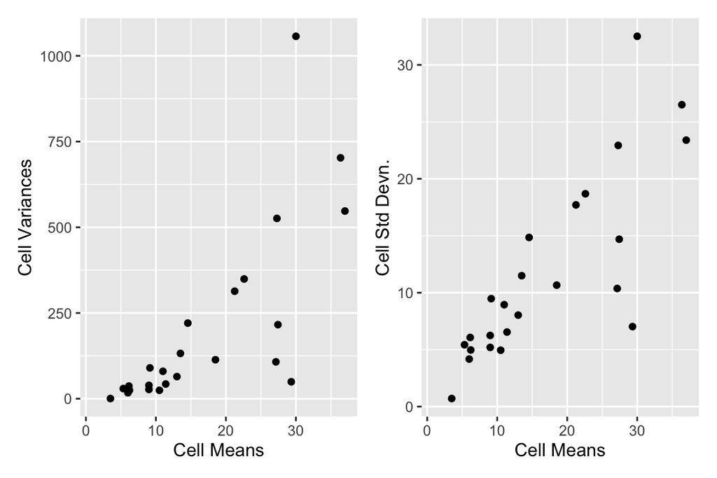

**Python**

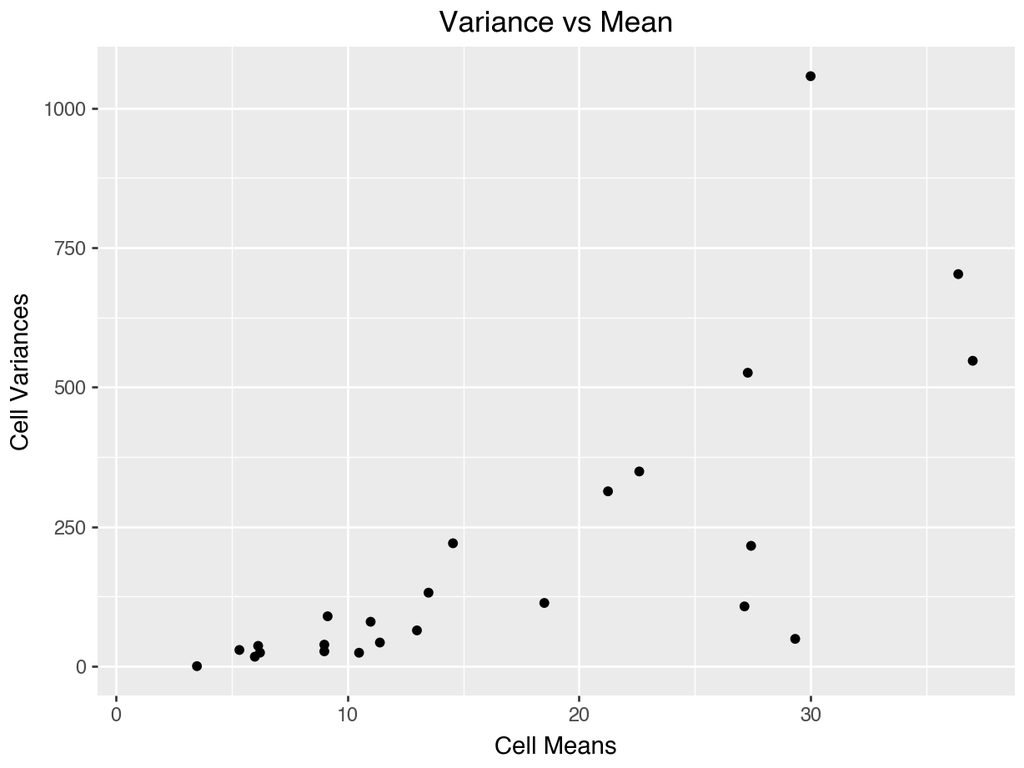

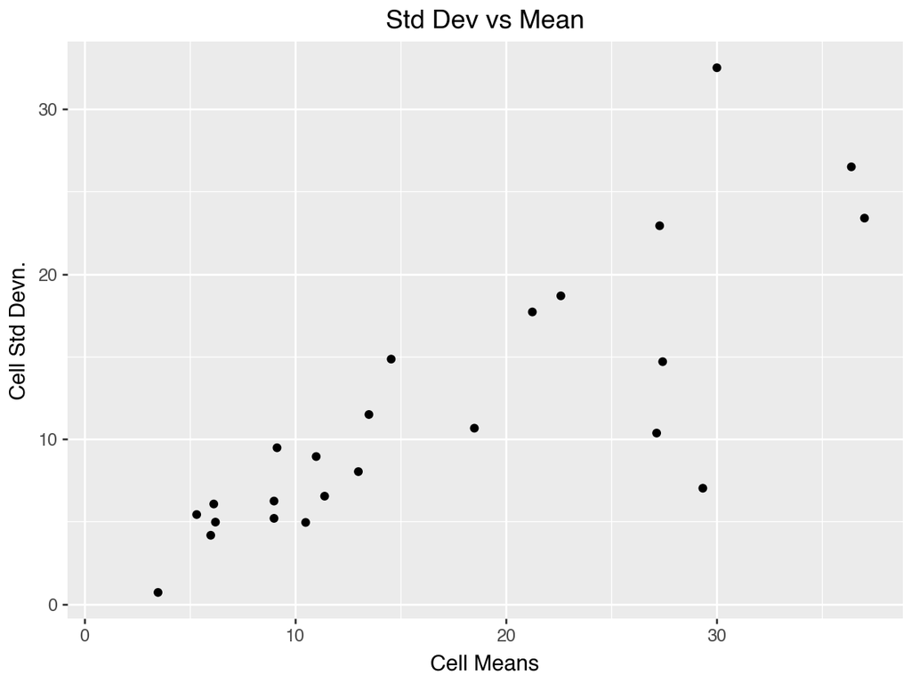

- 셀 평균에 대한 표준편차의 대략적인 선형성은 로그 변환 또는 그와 비슷한 것이 필요하다는 것을 암시한다.

### Box-Cox 변환

$$y^{(\lambda)}= \begin{cases}\left(y^\lambda-1\right) / \lambda & \lambda \neq 0 \\ \log y & \lambda=0\end{cases}$$

- Quine 자료에서는 $y = Days + \alpha$, $\alpha > 0$ (왜 그런가?)

#### 고정된 $\alpha$

- $\alpha=1$로 두자 (Aitkins, 1978).
- $\lambda$의 프로파일 가능도함수 (Box and Cox, 1964)
  $$\widehat{L}(\lambda) = \mathrm{const} - \frac{n}{2} \log \mathrm{RSS}(z^{(\lambda)}), \quad z^{(\lambda)} = y^{(\lambda)} / \dot{y}^{\lambda-1}$$
  - $\dot{y}$는 관측치의 기하 평균
  - $RSS(z^{(\lambda)})$는 $z^{(\lambda)}$에 대한 회귀모형의 잔차제곱합
  - 가장 큰 선형 모형을 사용하는 것이 바람직함.

**R**

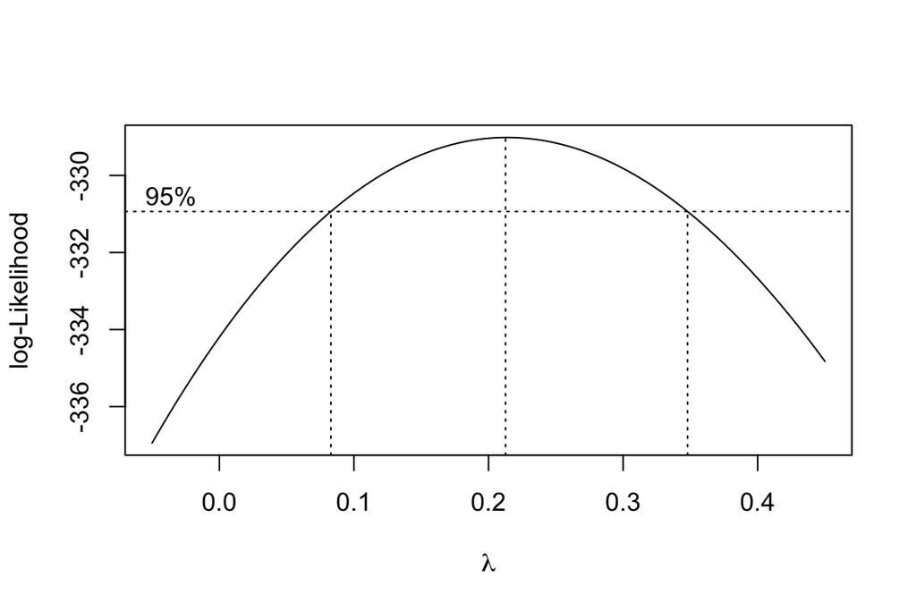

```r
MASS::boxcox(Days+1 ~ Eth * Sex * Age * Lrn, data = quine,
             singular.ok = TRUE,  lambda = seq(-0.05, 0.45, len = 20))
```

**Python**

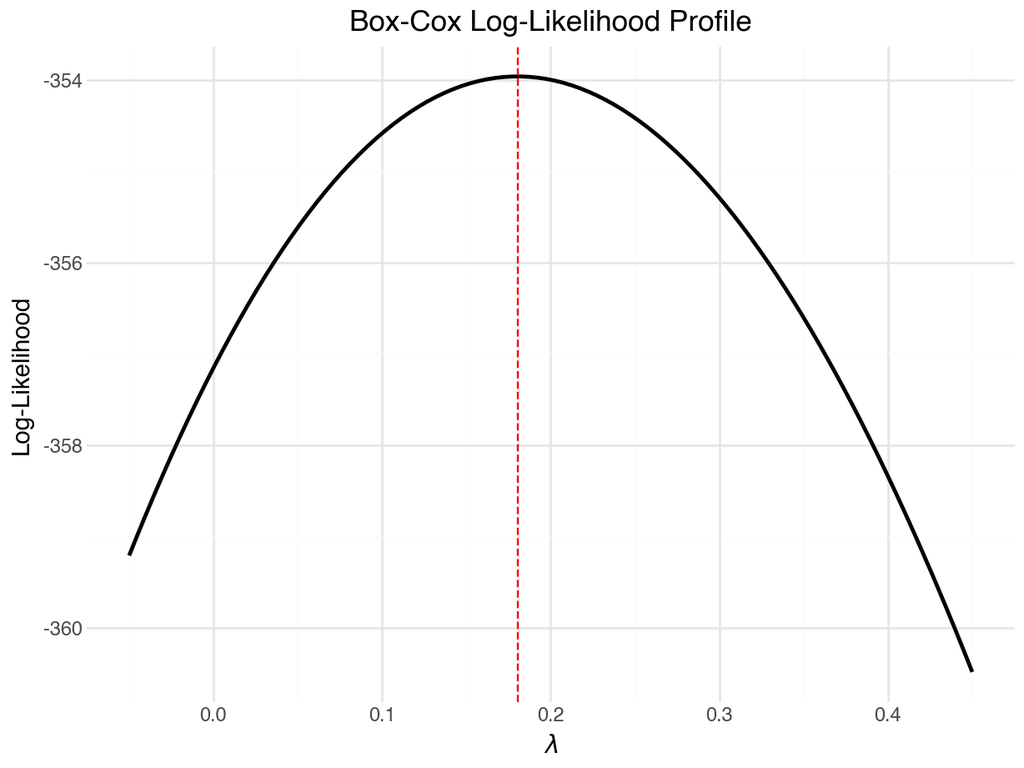

```python
from scipy import stats

quine = sm.datasets.get_rdataset("quine", "MASS").data
y = quine['Days'] + 1

lambdas = np.linspace(-0.05, 0.45, 100)
log_likelihoods = [stats.boxcox_llf(l, y) for l in lambdas]

df_profile = pd.DataFrame({'lambda': lambdas, 'llf': log_likelihoods})

opt_lambda = stats.boxcox_normmax(y, method='mle')

bc_plot = (
    ggplot(df_profile, aes(x='lambda', y='llf'))
    + geom_line(size=1)
    + geom_vline(xintercept=opt_lambda, linetype='dashed', color='red')
    + labs(
        title="Box-Cox Log-Likelihood Profile",
        x="$\lambda$",
        y="Log-Likelihood"
    )
    + theme_minimal()
)

bc_plot.show()
```

- `singular.ok`: 자료에 4개의 빈 셀이 있으므로 완전모형 `Days+1 ~ Eth * Sex * Age * Lrn`의 모형행렬은 랭크가 부족.

#### 로그 변환

- 위 그림은 $\alpha=1$일 때 로그 변환($\lambda=0$)이 최적이 아니라고 강하게 시사한다.
- 로그 변환을 고집한다면 고려할 수 있는 변환은 $t(y, \alpha) = \log(y + \alpha)$이다. Box and Cox (1964)에서와 같은 분석을 이용해 $\alpha$에 대한 프로파일 가능도가
  $$\hat{L}(\alpha) = \mathrm{const} - \frac{n}{2} \log\mathrm{RSS} \{ \log (y + \alpha) \} - \sum \log (y + \alpha)$$
  임을 쉽게 보일 수 있다.

**R**

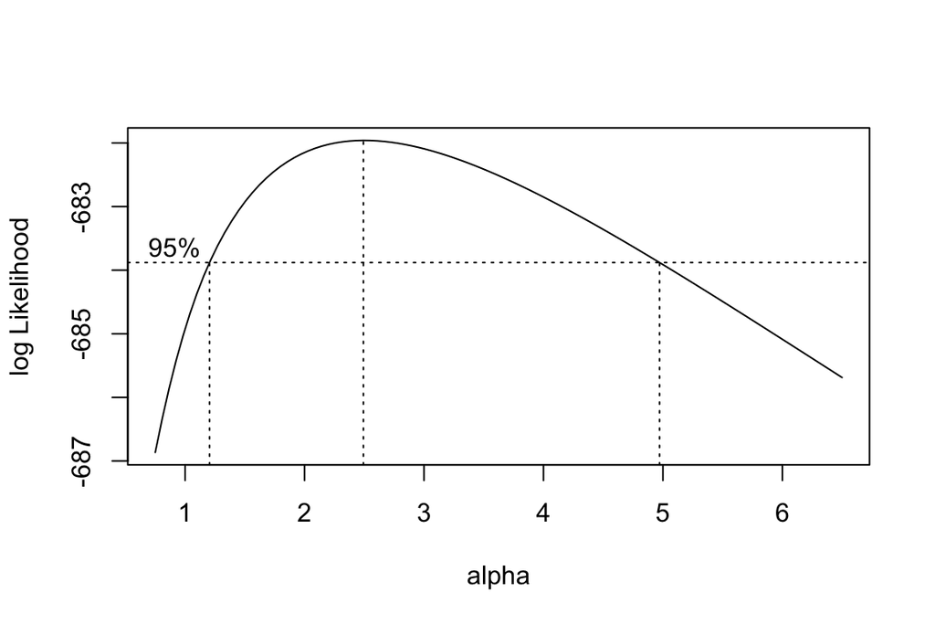

```r
MASS::logtrans(Days ~ Age*Sex*Eth*Lrn, data = quine,
               alpha = seq(0.75, 6.5, len = 20), singular.ok = TRUE)
```

**Python**

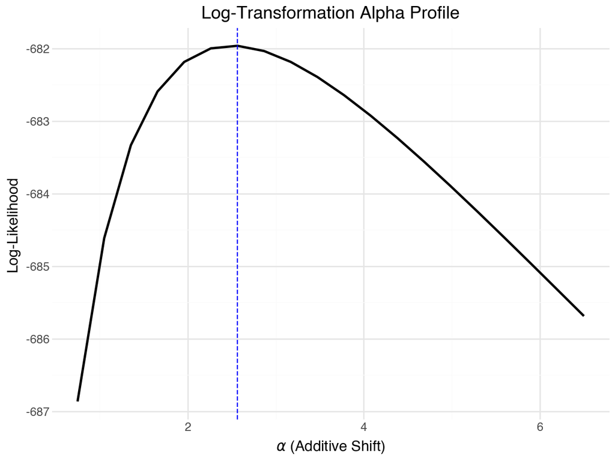

```python
y = quine['Days']

alphas = np.linspace(0.75, 6.5, 20)

def get_log_likelihood(a):
    shifted_y = np.log(y + a)
    model = smf.ols('shifted_y ~ Age * Sex * Eth * Lrn', data=quine).fit()
    residuals = model.resid
    rss = sum(residuals ** 2)
    loglik = - len(y) * np.log(rss)/2 - shifted_y.sum()
    return loglik

ll_profile = [get_log_likelihood(a) for a in alphas]
df_logtrans = pd.DataFrame({'alpha': alphas, 'll': ll_profile})
opt_alpha = df_logtrans.loc[df_logtrans['ll'].idxmax(), 'alpha']

logtrans_plot = (
    ggplot(df_logtrans, aes(x='alpha', y='ll'))
    + geom_line(size=1)
    + geom_vline(xintercept=opt_alpha, linetype='dashed', color='blue')
    + labs(
        title="Log-Transformation Alpha Profile",
        x="$\\alpha$ (Additive Shift)",
        y="Log-Likelihood"
    )
    + theme_minimal()
)
logtrans_plot.show()
```

- $\alpha=2.5$가 바람직하다. (Aitkins (1978)은 $\log(Days+1)$을 사용)

## 모형 선택

- 완전모형인 `Eth * Sex * Age * Lrn`은 식별된 그룹 하나하나마다 서로 다른 모수를 가지므로 보다 간단한 모형들을 모두 포함.
- 과적합으로 인해 예측력과 설명력이 작음.
- 평균에 대한 더 좋은 설명력과 예측력을 위해 가능한 한 모수의 수가 적은 경제적인 모형이 필요.
- 주변성 제한: 고차항이 있는 모형은 저차항을 포함. 예: 2차 회귀에서 $x^2$항이 있는 모형은 특별한 경우가 아닌 한 $x$항과 절편을 포함.

### 변수 선택

#### 후진선택

- 완전모형에서 4원 교호작용을 제외한 모형에서 3원 항을 제외한다면 어느 항을 제외해야 하는가?

**R**

```r
(quine.hi <- aov(log(Days + 2.5) ~ .^4, MASS::quine))  # 완전모형
```

```
Call:
   aov(formula = log(Days + 2.5) ~ .^4, data = MASS::quine)

Terms:
                     Eth      Sex      Age      Lrn  Eth:Sex  Eth:Age  Eth:Lrn
Sum of Squares  10.68203  0.62388  3.76424  0.65290  0.01533  5.98964  0.01246
Deg. of Freedom        1        1        3        1        1        3        1
                 Sex:Age  Sex:Lrn  Age:Lrn Eth:Sex:Age Eth:Sex:Lrn Eth:Age:Lrn
Sum of Squares   8.68925  0.57977  2.38640     1.93915     3.74062     2.14622
Deg. of Freedom        3        1        2           3           1           2
                Sex:Age:Lrn Eth:Sex:Age:Lrn Residuals
Sum of Squares      1.46623         0.78865  63.31035
Deg. of Freedom           2               2       118

Residual standard error: 0.732481
4 out of 32 effects not estimable
Estimated effects may be unbalanced
```

**Python**

```python
quine['log_days'] = np.log(quine['Days'] + 2.5)
quine_mod = smf.ols('log_days ~ (Eth + Sex + Age + Lrn)**4', data=quine).fit()
quine_hi = sm.stats.anova_lm(quine_mod, typ=1) # aov
quine_hi
```

```
                    df     sum_sq    mean_sq          F    PR(>F)
Eth                1.0  10.682027  10.682027  19.909527  0.000019
Sex                1.0   0.623876   0.623876   1.162801  0.283085
Age                3.0   3.764237   1.254746   2.338638  0.077043
Lrn                1.0   0.652902   0.652902   1.216900  0.272214
Eth:Sex            1.0   0.015329   0.015329   0.028571  0.866062
Eth:Age            3.0   5.989636   1.996545   3.721230  0.013393
Eth:Lrn            1.0   0.012456   0.012456   0.023216  0.879158
Sex:Age            3.0   8.689247   2.896416   5.398438  0.001623
Sex:Lrn            1.0   0.579772   0.579772   1.080599  0.300689
Age:Lrn            3.0   2.405999   0.802000   1.494794  0.219557
Eth:Sex:Age        3.0   1.920039   0.640013   1.192878  0.315574
Eth:Sex:Lrn        1.0   3.774057   3.774057   7.034217  0.009096
Eth:Age:Lrn        3.0   2.280176   0.760059   1.416623  0.241393
Sex:Age:Lrn        3.0   1.462900   0.487633   0.908868  0.439049
Eth:Sex:Age:Lrn    3.0   0.794719   0.264906   0.493742  0.687307
Residual         118.0  63.310351   0.536528        NaN       NaN
```

**R**

```r
quine.nxt <- update(quine.hi, . ~ . - Eth:Sex:Age:Lrn)
MASS::dropterm(quine.nxt, test = "F")
```

```
Single term deletions

Model:
log(Days + 2.5) ~ Eth + Sex + Age + Lrn + Eth:Sex + Eth:Age +
    Eth:Lrn + Sex:Age + Sex:Lrn + Age:Lrn + Eth:Sex:Age + Eth:Sex:Lrn +
    Eth:Age:Lrn + Sex:Age:Lrn
            Df Sum of Sq    RSS     AIC F Value   Pr(F)
<none>                   64.099 -68.184
Eth:Sex:Age  3   0.97387 65.073 -71.982 0.60773 0.61125
Eth:Sex:Lrn  1   1.57879 65.678 -66.631 2.95567 0.08816 .
Eth:Age:Lrn  2   2.12841 66.227 -67.415 1.99230 0.14087
Sex:Age:Lrn  2   1.46623 65.565 -68.882 1.37247 0.25743
---
Signif. codes:  0 '***' 0.001 '**' 0.01 '*' 0.05 '.' 0.1 ' ' 1
```

**Python**

```python
from scipy import stats

def dropterm(formula,dropvars):
    p = len(dropvars)
    org_mod = smf.ols(formula, data=quine).fit()
    org_aov = sm.stats.anova_lm(org_mod, typ=1)
    rss = [org_mod.ssr]
    aic = [org_mod.aic]
    df=[]
    df_mod=len(org_mod.params)-1

    results = pd.DataFrame(index=range(p+1), columns=['df', 'Sum of Sq', 'RSS', 'AIC', 'F value', 'Pr(F)'])
    results.index = ['<none>'] + dropvars

    for dropvar in dropvars:
        drop_mod = smf.ols(formula + '-' + dropvar, data=quine).fit()
        rss.append(drop_mod.ssr)
        aic.append(drop_mod.aic)
        df.append(df_mod-(len(drop_mod.params)-1))

    ss = rss-rss[0]
    results['Sum of Sq'] = ss
    results['RSS'] = rss
    results['AIC'] = aic
    results.iloc[1:(p+1), 0] = df
    results.iloc[1:(p+1), 4] = ss[1:]/df

    for i in range(1,(p+1)):
        results.iloc[i, 5] = stats.f.sf(results.iloc[i, 4], df[i-1], df_mod-df[i-1])

    return results

formula = 'log_days ~ (Eth + Sex + Age + Lrn)**4 - Eth:Sex:Age:Lrn'
dropvars = ['Eth:Sex:Age','Eth:Sex:Lrn','Eth:Age:Lrn','Sex:Age:Lrn']

dropterm(formula,dropvars)
```

```
              df  Sum of Sq        RSS         AIC   F value     Pr(F)
<none>       NaN   0.000000  64.099002  346.146088       NaN       NaN
Eth:Sex:Age    3   0.973869  65.072871  342.347613  0.324623  0.807515
Eth:Sex:Lrn    1   1.578795  65.677796  347.698578  1.578795  0.219697
Eth:Age:Lrn    3   2.128409  66.227410  346.915272   0.70947  0.555451
Sex:Age:Lrn    3   1.466230  65.565232  345.448135  0.488743   0.69322
```

- `Eth:Sex:Age`를 제외시키면 AIC가 가장 크게 줄어든다.
- 일반적인 F 검정에서는 모든 3원 항이 유의하지 않다.

#### AIC

- AIC는 일반적으로 다음과 같이 정의된다 (Akaike, 1974).

  ```
      AIC = -2(maximized log-likelihood) + 2(# parameters)
  ```

- $n$개의 관측치, $p$개의 모수들, 정규분포를 따르는 잔차들을 갖는 회귀모형에 대해 로그 가능도는
  $$L(\beta, \alpha^{2}; \boldsymbol{y}) = \mathrm{const} - \frac{n}{2} \log \sigma^2 - \frac{1}{2 \sigma^2} \| \boldsymbol{y}-X \boldsymbol{\beta} \|^2$$
- $\widehat{\beta}$가 $\beta$에 대해 (로그)가능도함수를 최대화하는 값이라 하자. 그러면
  $$L(\widehat{\beta}, \alpha^{2}; \boldsymbol{y}) = \mathrm{const} - \frac{n}{2} \log \sigma^2 - \frac{1}{2 \sigma^2} \mathrm{RSS}$$
- $\sigma^2$의 값이 알려져 있다면
  $$\text{AIC} = \frac{\text{RSS}}{\sigma^2} + 2p + \text{const}$$
  이는 Mallow’s $C_p$와 동등하다.
  $$C_p = \text{RSS}/ \sigma^2 + 2p - n$$
- $\sigma^2$의 값이 알려져 있지 않다면
  $$L(\widehat{\beta}, \widehat{\alpha}^{2}; \boldsymbol{y}) = \text{const} - \frac{n}{2}\log \widehat{\sigma}^2 - \frac{n}{2}, \quad \widehat{\sigma}^2 = \text{RSS}/n$$
  이므로
  $$\text{AIC} = n \log (\text{RSS}/n) + 2p + const$$

#### 전진선택

- 가장 간단한 모형에서 시작해 AIC 값이 줄어드는 항을 추가하는 방법

**R**

```r
quine.lo <- aov(log(Days+2.5) ~ 1, quine)
MASS::addterm(quine.lo, quine.hi, test = "F")
```

```
Single term additions

Model:
log(Days + 2.5) ~ 1
       Df Sum of Sq     RSS     AIC F Value     Pr(F)
<none>              106.787 -43.664
Eth     1   10.6820  96.105 -57.052 16.0055 0.0001006 ***
Sex     1    0.5969 106.190 -42.483  0.8094 0.3698057
Age     3    4.7469 102.040 -44.303  2.2019 0.0904804 .
Lrn     1    0.0043 106.783 -41.670  0.0058 0.9392083
---
Signif. codes:  0 '***' 0.001 '**' 0.01 '*' 0.05 '.' 0.1 ' ' 1
```

**Python**

```python
import statsmodels.api as sm

formula ='log_days ~ 1'
quine_lo_mod = smf.ols(formula, data=quine).fit()
quine_lo = sm.stats.anova_lm(quine_lo_mod, typ=1)
quine_lo
```

```
             df      sum_sq   mean_sq   F  PR(>F)
Residual  145.0  106.787104  0.736463 NaN     NaN
```

```python
rss = [quine_lo_mod.ssr]
aic = [quine_lo_mod.aic]
df=[]

addvars = ['Eth','Sex','Age','Lrn']
results = pd.DataFrame(index=range(5), columns=['df', 'Sum of Sq', 'RSS', 'AIC', 'F value', 'Pr(F)'])
results.index = ['<none>'] + addvars

for addvar in addvars:
    quine_nxtnxt_mod = smf.ols(formula + '+' + addvar, data=quine).fit()
    rss.append(quine_nxtnxt_mod.ssr)
    aic.append(quine_nxtnxt_mod.aic)
    df.append((len(quine_nxtnxt_mod.params)-1))

ss = rss[0]-rss
results['Sum of Sq'] = ss
results['RSS'] = rss
results['AIC'] = aic
results.iloc[1:5, 0] = df
results.iloc[1:5, 4] = ss[1:]/df

for i in range(1,5):
    results.iloc[i, 5] = stats.f.sf(results.iloc[i, 4], df[i-1], df[i-1])

results
```

```
         df  Sum of Sq         RSS         AIC    F value     Pr(F)
<none>  NaN   0.000000  106.787104  370.665711        NaN       NaN
Eth       1  10.682027   96.105077  357.278038  10.682027  0.189026
Sex       1   0.596863  106.190241  371.847388   0.596863  0.581238
Age       3   4.746893  102.040211  370.027061   1.582298  0.357671
Lrn       1   0.004328  106.782775  372.659794   0.004328  0.958178
```

- `Eth`, `Age`만 (통계적으로) 유용한 것으로 보임.
- 궁극적으로는 높은 차수의 교호작용들이 잔차제곱합을 크게 줄여 모든 주효과 인자가 필요

### 단계적 선택

- `MASS::stepAIC`: 단계별 선택 절차를 자동화
  - 시작 적합 모형(최종 모델에 가까운 모델이 유리할 수 있음)
  - 절차의 상위(가장 복잡) 및 하위(가장 간단) 모형을 정의하는 두 개의 공식 `list` 등이 필요

```r
quine.stp <- MASS::stepAIC(quine.nxt,
                           scope = list(upper = ~ Eth*Sex*Age*Lrn,
                                        lower = ~1),
                           trace = F)
quine.stp$anova
```

```
Stepwise Model Path
Analysis of Deviance Table

Initial Model:
log(Days + 2.5) ~ Eth + Sex + Age + Lrn + Eth:Sex + Eth:Age +
    Eth:Lrn + Sex:Age + Sex:Lrn + Age:Lrn + Eth:Sex:Age + Eth:Sex:Lrn +
    Eth:Age:Lrn + Sex:Age:Lrn

Final Model:
log(Days + 2.5) ~ Eth + Sex + Age + Lrn + Eth:Sex + Eth:Age +
    Eth:Lrn + Sex:Age + Sex:Lrn + Age:Lrn + Eth:Sex:Lrn + Eth:Age:Lrn

           Step Df Deviance Resid. Df Resid. Dev       AIC
1                                 120   64.09900 -68.18396
2 - Eth:Sex:Age  3 0.973869       123   65.07287 -71.98244
3 - Sex:Age:Lrn  2 1.526754       125   66.59962 -72.59652
```

- 남은 비주변 항의 유의성 확인

  ```r
  MASS::dropterm(quine.stp, test = "F")
  ```

  ```
  Single term deletions

  Model:
  log(Days + 2.5) ~ Eth + Sex + Age + Lrn + Eth:Sex + Eth:Age +
      Eth:Lrn + Sex:Age + Sex:Lrn + Age:Lrn + Eth:Sex:Lrn + Eth:Age:Lrn
              Df Sum of Sq    RSS     AIC F Value     Pr(F)
  <none>                   66.600 -72.597
  Sex:Age      3   10.7959 77.396 -56.663  6.7542 0.0002933 ***
  Eth:Sex:Lrn  1    3.0325 69.632 -68.096  5.6916 0.0185476 *
  Eth:Age:Lrn  2    2.0960 68.696 -72.072  1.9670 0.1441822
  ---
  Signif. codes:  0 '***' 0.001 '**' 0.01 '*' 0.05 '.' 0.1 ' ' 1
  ```

  `Eth:Age:Lrn` 항은 5% 유의수준에서 유의하지 않다.
- 이는 AIC에 근거해 선택한 항들이 다소 관대함을 시사. 더 경제적인 모형을 얻기 위해 수동 제거

  ```r
  quine.3 <- update(quine.stp, . ~ . - Eth:Age:Lrn)
  MASS::dropterm(quine.3, test = "F")
  ```

  ```
  Single term deletions

  Model:
  log(Days + 2.5) ~ Eth + Sex + Age + Lrn + Eth:Sex + Eth:Age +
      Eth:Lrn + Sex:Age + Sex:Lrn + Age:Lrn + Eth:Sex:Lrn
              Df Sum of Sq    RSS     AIC F Value     Pr(F)
  <none>                   68.696 -72.072
  Eth:Age      3    3.0312 71.727 -71.768  1.8679 0.1383323
  Sex:Age      3   11.4272 80.123 -55.607  7.0419 0.0002037 ***
  Age:Lrn      2    2.8149 71.511 -70.209  2.6020 0.0780701 .
  Eth:Sex:Lrn  1    4.6956 73.391 -64.419  8.6809 0.0038268 **
  ---
  Signif. codes:  0 '***' 0.001 '**' 0.01 '*' 0.05 '.' 0.1 ' ' 1
  ```

```r
    quine.4 <- update(quine.3, . ~ . - Eth:Age)
    MASS::dropterm(quine.4, test = "F")
```

```
Single term deletions

Model:
log(Days + 2.5) ~ Eth + Sex + Age + Lrn + Eth:Sex + Eth:Lrn +
    Sex:Age + Sex:Lrn + Age:Lrn + Eth:Sex:Lrn
            Df Sum of Sq    RSS     AIC F Value     Pr(F)
<none>                   71.727 -71.768
Sex:Age      3   11.5656 83.292 -55.942  6.9873 0.0002147 ***
Age:Lrn      2    2.9118 74.639 -69.959  2.6387 0.0752793 .
Eth:Sex:Lrn  1    6.8181 78.545 -60.511 12.3574 0.0006052 ***
---
Signif. codes:  0 '***' 0.001 '**' 0.01 '*' 0.05 '.' 0.1 ' ' 1
```

```r
    quine.5 <- update(quine.4, . ~ . - Age:Lrn)
    MASS::dropterm(quine.5, test = "F")
```

```
Single term deletions

Model:
log(Days + 2.5) ~ Eth + Sex + Age + Lrn + Eth:Sex + Eth:Lrn +
    Sex:Age + Sex:Lrn + Eth:Sex:Lrn
            Df Sum of Sq    RSS     AIC F Value     Pr(F)
<none>                   74.639 -69.959
Sex:Age      3    9.9002 84.539 -57.774  5.8362 0.0008944 ***
Eth:Sex:Lrn  1    6.2988 80.937 -60.130 11.1396 0.0010982 **
---
Signif. codes:  0 '***' 0.001 '**' 0.01 '*' 0.05 '.' 0.1 ' ' 1
```

- Aitkin (1978)이 얻은 최종모형과 동일

# 다중 비교

## 다중비교 조정

- 사전에 계획된 실험에 의해 이루어지는 회귀분석에서 대조(contrast)에 대한 다중비교는 사후에 조정할 수 있다(post hoc adjustment).
- 9강 참조

## Immer 자료

**R**

```r
as.tibble(MASS::immer)  # 보리 생산량에 대한 실험자료
```

```
# A tibble: 30 × 4
   Loc   Var      Y1    Y2
   <fct> <fct> <dbl> <dbl>
 1 UF    M      81    80.7
 2 UF    S     105.   82.3
 3 UF    V     120.   80.4
 4 UF    T     110.   87.2
 5 UF    P      98.3  84.2
 6 W     M     147.  100.
 7 W     S     142   116.
 8 W     V     151.  112.
 9 W     T     192.  148.
10 W     P     146.  108.
# ℹ 20 more rows
```

**Python**

```python
immer = sm.datasets.get_rdataset("immer", "MASS").data
```

- 변수
  - `Loc`: 실험농장 (6개)
  - `Var`: 보리 품종 (5가지)
  - `Y1`: 1931년 보리 생산량
  - `Y2`: 1932년 보리 생산량
- 관심사 : 품종별 생산량 차이

**R**

```r
immer.aov <- aov((Y1 + Y2)/2 ~ Var + Loc, data = immer)  # 2년간 평균 생산량 분석
summary(immer.aov)
```

```
            Df Sum Sq Mean Sq F value   Pr(>F)
Var          4   2655   663.7   5.989  0.00245 **
Loc          5  10610  2122.1  19.148 5.21e-07 ***
Residuals   20   2217   110.8
---
Signif. codes:  0 '***' 0.001 '**' 0.01 '*' 0.05 '.' 0.1 ' ' 1
```

**Python**

```python
model = smf.ols('I((Y1 + Y2) / 2) ~ C(Var) + C(Loc)', data=immer).fit()
anova_table = sm.stats.anova_lm(model, typ=1)
print(anova_table)
```

```
            df        sum_sq      mean_sq          F        PR(>F)
C(Var)     4.0   2654.986167   663.746542   5.989117  2.452645e-03
C(Loc)     5.0  10610.452000  2122.090400  19.148044  5.211935e-07
Residual  20.0   2216.508833   110.825442        NaN           NaN
```

품종별 생산량은 통계적으로 유의한 차이가 있다.

- 품종별 평균 생산량

**R**

```r
model.tables(immer.aov, type = "means", se = TRUE, cterms = "Var")
```

```
Tables of means
Grand mean

101.09

 Var
Var
     M      P      S      T      V
 94.39 102.54  91.13 118.20  99.18

Standard errors for differences of means
          Var
        6.078
replic.     6
```

**Python**

```python
group_means = immer.groupby('Var')[['Y1', 'Y2']].mean().mean(axis=1)
means_df = group_means.to_frame(name='Mean Yield')

ms_error = anova_table.loc['Residual', 'mean_sq']
n_i = len(immer) / len(immer['Var'].unique())

se_mean = np.sqrt(ms_error / n_i)

means_df['Std.Error'] = se_mean
print("--- Tables of Means for Variety ---")
```

```
--- Tables of Means for Variety ---
```

```python
print(means_df)
```

```
     Mean Yield  Std.Error
Var
M     94.391667   4.297779
P    102.541667   4.297779
S     91.133333   4.297779
T    118.200000   4.297779
V     99.183333   4.297779
```

- 유의수준 5%에서 평균 생산량의 차이에 대한 쌍별 검정을 한다면 $6.078 \times t_{20}(0.975) \approx 12.6$이므로 품종 `T`와 다른 품종들간의 평균 생산량 차이는 유의할 것이라는 것을 시사한다.
- 하지만 이 비교는 적합 결과를 본 후에 정해진 것이다. 즉, 명시적으로 계산되지 않더라도 다른 모든 비교가 암시적으로 이루어진 것이다.
- 적합을 확인하기 전에 비교가 결정되었다고 받아들일 수 있다면 단순 조정을 행할 수 있으나 이런 경우는 거의 없으며, 더 나아가 이것이 정말로 사용자의 의도였다고 다른 사람들을 설득하기 어려울 수 있다.
- 따라서 모든 쌍별 비교에 대해 조정을 행하는 것이 일반적이다.
- 동시 신뢰구간

```r
(tk <- confint(multcomp::glht(immer.aov, linfct = mcp(Var = "Tukey"))) )
```

```
     Simultaneous Confidence Intervals

Multiple Comparisons of Means: Tukey Contrasts


Fit: aov(formula = (Y1 + Y2)/2 ~ Var + Loc, data = immer)

Quantile = 2.9923
95% family-wise confidence level


Linear Hypotheses:
           Estimate lwr      upr
P - M == 0   8.1500 -10.0369  26.3369
S - M == 0  -3.2583 -21.4453  14.9286
T - M == 0  23.8083   5.6214  41.9953
V - M == 0   4.7917 -13.3953  22.9786
S - P == 0 -11.4083 -29.5953   6.7786
T - P == 0  15.6583  -2.5286  33.8453
V - P == 0  -3.3583 -21.5453  14.8286
T - S == 0  27.0667   8.8797  45.2536
V - S == 0   8.0500 -10.1369  26.2369
V - T == 0 -19.0167 -37.2036  -0.8297
```

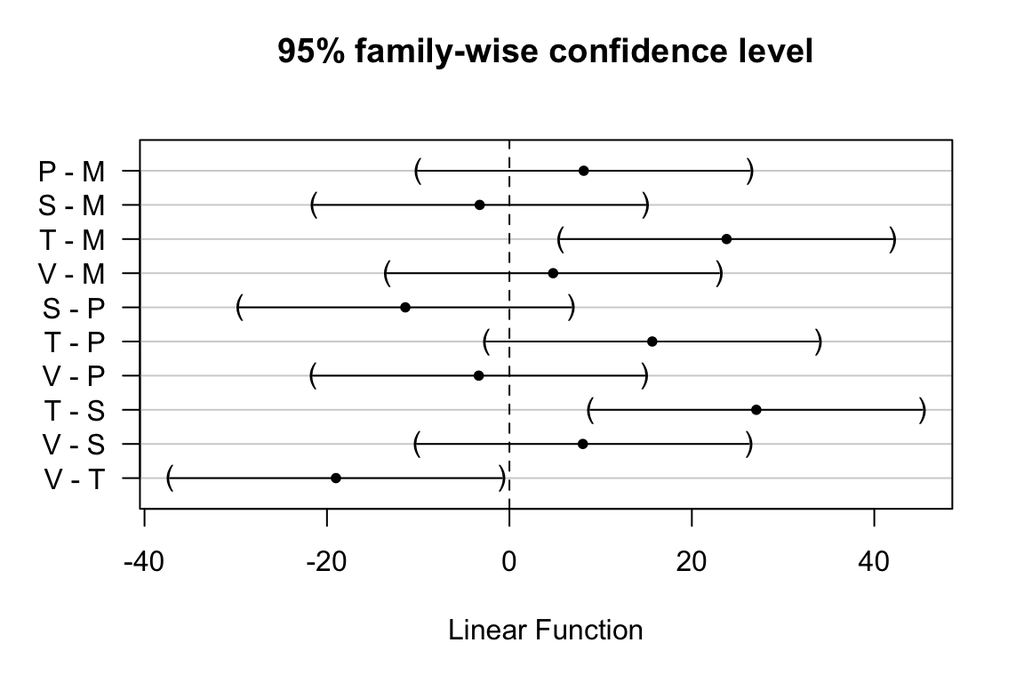

```r
plot(tk)
```

- 품종 `T`의 수확량이 품종 `P`와 크게 다르다는 결론을 내릴 수 없다.

## Oats 자료

```r
as.tibble(MASS::oats)
```

```
# A tibble: 72 × 4
   B     V           N          Y
   <fct> <fct>       <fct>  <int>
 1 I     Victory     0.0cwt   111
 2 I     Victory     0.2cwt   130
 3 I     Victory     0.4cwt   157
 4 I     Victory     0.6cwt   174
 5 I     Golden.rain 0.0cwt   117
 6 I     Golden.rain 0.2cwt   114
 7 I     Golden.rain 0.4cwt   161
 8 I     Golden.rain 0.6cwt   141
 9 I     Marvellous  0.0cwt   105
10 I     Marvellous  0.2cwt   140
# ℹ 62 more rows
```

```r
oats1 <- aov(Y ~ N + V + B, data = oats)
summary(oats1)
```

```
            Df Sum Sq Mean Sq F value   Pr(>F)
N            3  20020    6673  28.460 1.24e-11 ***
V            2   1786     893   3.809   0.0276 *
B            5  15875    3175  13.540 6.91e-09 ***
Residuals   61  14304     234
---
Signif. codes:  0 '***' 0.001 '**' 0.01 '*' 0.05 '.' 0.1 ' ' 1
```

```r
confint(glht(oats1, linfct = mcp(V = "Tukey")))
```

```
     Simultaneous Confidence Intervals

Multiple Comparisons of Means: Tukey Contrasts


Fit: aov(formula = Y ~ N + V + B, data = oats)

Quantile = 2.403
95% family-wise confidence level


Linear Hypotheses:
                              Estimate lwr      upr
Marvellous - Golden.rain == 0   5.2917  -5.3306  15.9139
Victory - Golden.rain == 0     -6.8750 -17.4973   3.7473
Victory - Marvellous == 0     -12.1667 -22.7889  -1.5444
```

- 대조군과의 비교

```r
lmat <- matrix(c(0, -1, 1, rep(0, 11),
                 0, -1, 0, 1, rep(0,10),
                 0, -1, 0, 0, 1, rep(0,9)), , 3, dimnames = list(NULL,
               c("0.2cwt-0.0cwt", "0.4cwt-0.0cwt", "0.6cwt-0.0cwt")))
lmat
```

```
      0.2cwt-0.0cwt 0.4cwt-0.0cwt 0.6cwt-0.0cwt
 [1,]             0             0             0
 [2,]            -1            -1            -1
 [3,]             1             0             0
 [4,]             0             1             0
 [5,]             0             0             1
 [6,]             0             0             0
 [7,]             0             0             0
 [8,]             0             0             0
 [9,]             0             0             0
[10,]             0             0             0
[11,]             0             0             0
[12,]             0             0             0
[13,]             0             0             0
[14,]             0             0             0
```

```r
confint(glht(oats1, linfct = mcp(N = t(lmat[2:5, ]))))
```

```
     Simultaneous Confidence Intervals

Multiple Comparisons of Means: User-defined Contrasts


Fit: aov(formula = Y ~ N + V + B, data = oats)

Quantile = 2.4081
95% family-wise confidence level


Linear Hypotheses:
                   Estimate lwr     upr
0.2cwt-0.0cwt == 0 19.5000   7.2080 31.7920
0.4cwt-0.0cwt == 0 34.8333  22.5414 47.1253
0.6cwt-0.0cwt == 0 44.0000  31.7080 56.2920
```

- 모든 질소 증가가 생산량에 유의미한 증가로 이어지는지 알아보자.

```r
lmat <- matrix(c(0,-1,1,rep(0, 11), 0,0,-1,1, rep(0,10),
                 0,0,0,-1,1,rep(0,9)),,3,
               dimnames = list(NULL,
               c("0.2cwt-0.0cwt", "0.4cwt-0.2cwt", "0.6cwt-0.4cwt")))
lmat
```

```
      0.2cwt-0.0cwt 0.4cwt-0.2cwt 0.6cwt-0.4cwt
 [1,]             0             0             0
 [2,]            -1             0             0
 [3,]             1            -1             0
 [4,]             0             1            -1
 [5,]             0             0             1
 [6,]             0             0             0
 [7,]             0             0             0
 [8,]             0             0             0
 [9,]             0             0             0
[10,]             0             0             0
[11,]             0             0             0
[12,]             0             0             0
[13,]             0             0             0
[14,]             0             0             0
```

```r
confint(glht(oats1, linfct = mcp(N = t(lmat[2:5, ])), alternative = "greater"))
```

```
     Simultaneous Confidence Intervals

Multiple Comparisons of Means: User-defined Contrasts


Fit: aov(formula = Y ~ N + V + B, data = oats)

Quantile = -2.1724
95% family-wise confidence level


Linear Hypotheses:
                   Estimate lwr     upr
0.2cwt-0.0cwt <= 0 19.5000   8.4113     Inf
0.4cwt-0.2cwt <= 0 15.3333   4.2446     Inf
0.6cwt-0.4cwt <= 0  9.1667  -1.9220     Inf
```